# Forecast Analysis

## Problem set

You will be using your model_id, climatology and persistence in the analysis below. You will be using site_ids BARC and SUGG (since they have year-around data)

Find your forecast scores here:

https://radiantearth.github.io/stac-browser/#/external/raw.githubusercontent.com/eco4cast/neon4cast-ci/main/catalog/scores/collection.json

climatology and persistenceRW are the null model_id

### Loading data

```r
library(arrow)
library(tidyverse)
library(ggplot2)


all_results <- arrow::open_dataset("s3://anonymous@bio230014-bucket01/challenges/scores/parquet/project_id=neon4cast/duration=P1D/variable=temperature?endpoint_override=sdsc.osn.xsede.org")
df_with_baselines <- all_results |>
  filter(site_id %in% c("BARC", "SUGG"),
         reference_datetime > as_date("2024-03-01"),
         model_id %in% c("lm_AT_WTL_WS", "climatology", "persistenceRW")) |>
  collect()

df_with_baselines$reference_datetime <- as.Date(df_with_baselines$reference_datetime)
df_with_baselines$datetime <- as.Date(df_with_baselines$datetime)
df_with_baselines$pub_datetime <- as.Date(df_with_baselines$pub_datetime)
df_with_baselines$date <- as.Date(df_with_baselines$date)
```

### Question 1

Plot climatology, persistence, and your model for a single forecast day (one reference_datetime) on the same plot. Use geom_ribbon to plot the uncertainty, geom_line to plot the median, and geom_point to plot the observations.

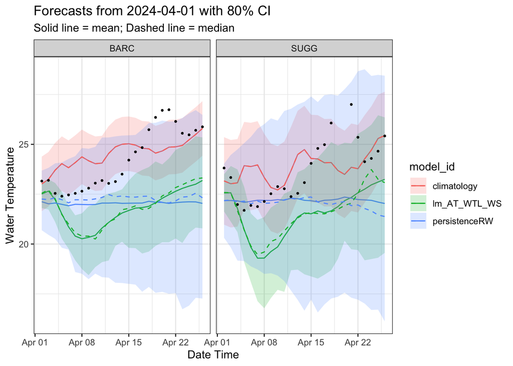

```r
df_with_baselines %>% filter(reference_datetime == "2024-04-01") %>%
  ggplot() +
  geom_line(aes(x=datetime, y=mean, group=model_id, color=model_id)) +
  geom_ribbon(aes(x=datetime, ymin=quantile10, ymax=quantile90, group=model_id, fill=model_id), alpha = 0.2) +
  geom_line(aes(x=datetime, y=median, group=model_id, color=model_id), linetype=2)+
  facet_wrap(vars(site_id)) +
  theme_bw() +
  labs(x="Date Time", y = "Water Temperature", title="Forecasts from 2024-04-01 with 80% CI", subtitle="Solid line = mean; Dashed line = median") +
  geom_point(aes(x=datetime, y=observation), color="black", size=0.5)
```

### Question 2

Based on visual inspection of your plot, how do the median of model differ in how they represent the observations.

### Question 3

Based on visual inspection of your plot, how does the uncertainty of each model forecasts differ in capacity to represent the observations.

Because the persistance model has the greatest uncertainty, it captures the most observed data values compared to the other models. While my model follows a similar shape to the data, most of the observed data are not captured by the confidence interval because the median values are off. The climatology model captures the majority of data points within the uncertainty bounds, even if the observed data do not follow the same trend shape as the model’s median.

### Question 4

Calculate the mean CRPS for the three models (averaged across all horizons, sites, and reference_datetimes). Which model has the lower score?

```r
df_with_baselines |>
  select(model_id, crps, datetime, reference_datetime, site_id) |>
  pivot_wider(names_from = model_id, values_from = crps) |>
  na.omit() |>
  pivot_longer(-c(datetime, reference_datetime, site_id), names_to = "model_id", values_to = "crps") |>
  summarise(mean_crps = mean(crps), .by = c("model_id"))
```

```
# A tibble: 3 × 2
  model_id      mean_crps
  <chr>             <dbl>
1 climatology       0.790
2 lm_AT_WTL_WS      1.18
3 persistenceRW     1.19
```

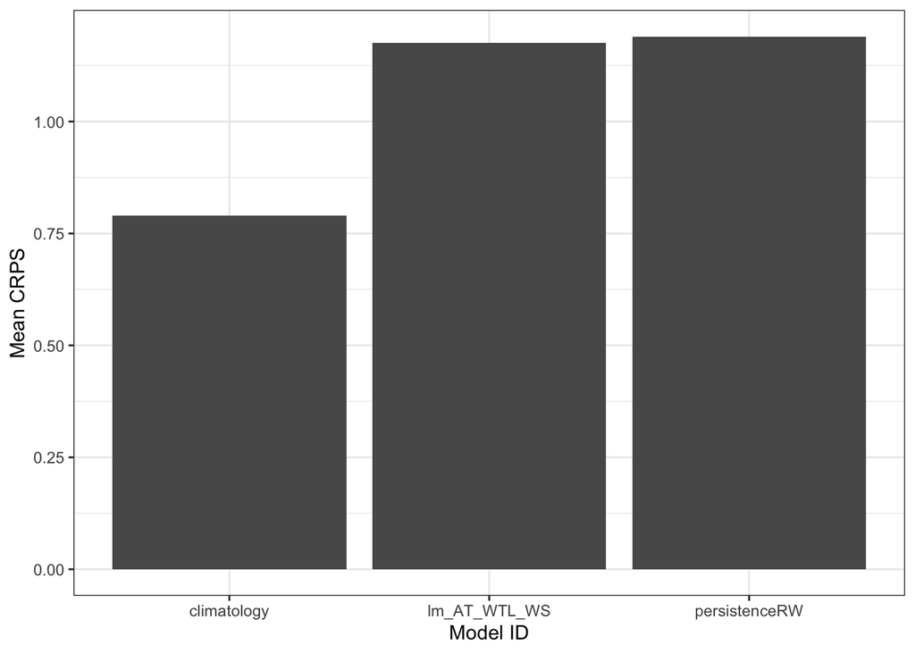

```r
df_with_baselines |>
  select(model_id, crps, datetime, reference_datetime, site_id) |>
  pivot_wider(names_from = model_id, values_from = crps) |>
  na.omit() |>
  pivot_longer(-c(datetime, reference_datetime, site_id), names_to = "model_id", values_to = "crps") |>
  summarise(mean_crps = mean(crps), .by = c("model_id")) |>
  ggplot(aes(x = model_id, y = mean_crps)) +
  geom_bar(stat="identity") +
  theme_bw() +
  labs(y="Mean CRPS", x="Model ID")
```

### Question 5

Plot the mean CRPS vs horizon for all three models. How does the performance change as you forecast further in the future?

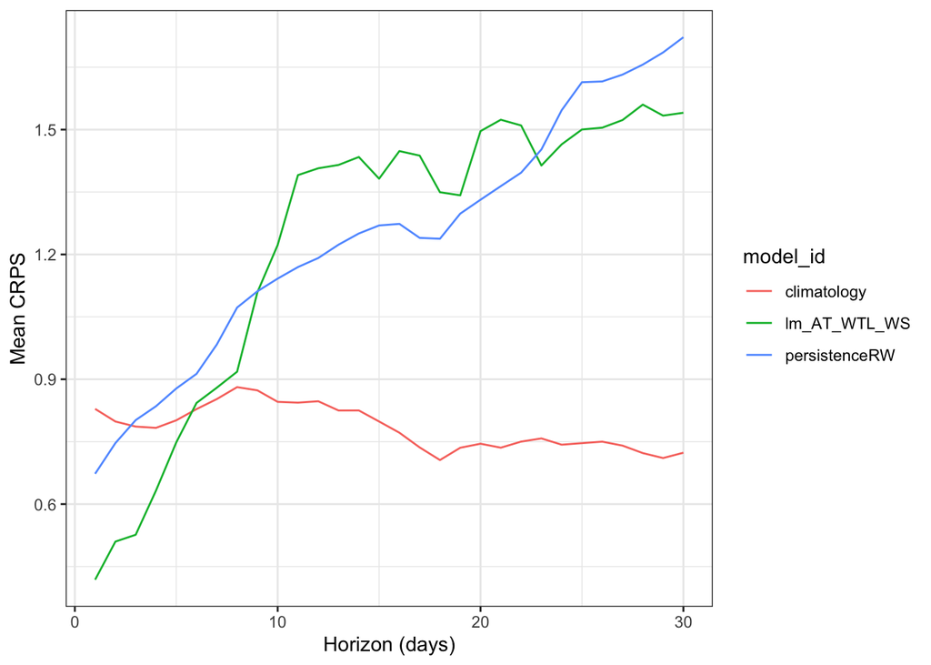

```r
df_with_baselines |>
  mutate(horizon = as.numeric(datetime - reference_datetime)) |>
  select(model_id, horizon, datetime, reference_datetime, crps, site_id) |>
  pivot_wider(names_from = model_id, values_from = crps) |>
  na.omit() |>
  pivot_longer(-c(horizon, datetime, reference_datetime, site_id), names_to = "model_id", values_to = "crps") |>
  summarize(mean_crps = mean(crps), .by = c("model_id", "horizon")) |>
  ggplot(aes(x = horizon, y = mean_crps, color = model_id)) +
  geom_line() +
  theme_bw() +
  labs(y="Mean CRPS", x="Horizon (days)")
```

### Question 6

Plot the mean CRPS separately for each site_id for all three models. How does performance differ between sites?

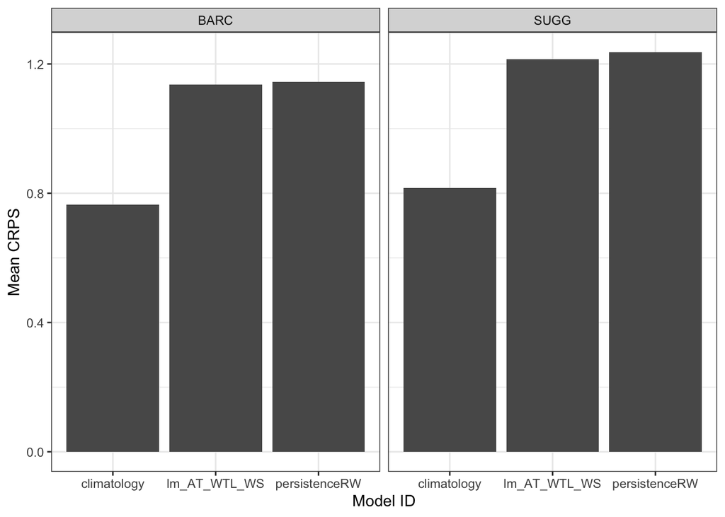

```r
df_with_baselines |>
  select(model_id, crps, datetime, reference_datetime, site_id) |>
  pivot_wider(names_from = model_id, values_from = crps) |>
  na.omit() |>
  pivot_longer(-c(datetime, reference_datetime, site_id), names_to = "model_id", values_to = "crps") |>
  summarise(mean_crps = mean(crps), .by = c("model_id", "site_id")) |>
  ggplot(aes(x = model_id, y = mean_crps)) +
  geom_bar(stat="identity") +
  theme_bw() +
  labs(y="Mean CRPS", x="Model ID") +
  facet_wrap(vars(site_id))
```

### Question 7

Which forecasting best practices are addressed with your forecasts and the analysis above? See https://frec-5174.github.io/eco4cast-in-R-book/best-practices.html.

My model accomplishes most of the best practices suggested by Lewis et al (2022). It includes uncertainty, has an automated workflow, follows an iterative process, and through the forecast submission to NEON, makes data available and archives forecasts. This assignment and analysis compares modeling approaches and compares my forecast to null models. My forecast does not identify an end user or report forecast accuracy. To address the first of the missing best practices, an end user for my forecast could be fish hatcheries manager looking to introduce new fish stocks to the lakes. However, I would suggest they use a different forecast based on my forecast scores.